# COMP60711 - Part 2 Coursework 2

| Course Unit: | COMP60711: Data Engineering |
| --- | --- |
| Responsible Staff Member: | Professor John Keane |
| Marks: | This coursework is worth **25%** of the overall marks for this unit. |
| Submissions: | This is the **4th** of **4** assessed submissions. |
| Method of Submitting: | This notebook, after completion, should be saved as a HTML document and submitted using Blackboard |
| Deadline: | Thursday 31st October 10AM (UK time) |
| Late Submissions: | Extensions will only be granted as a result of formally processed [Mitigating Circumstances](http://documents.manchester.ac.uk/DocuInfo.aspx?DocID=427). Marks for late submissions will be reduced in l… |

Please complete the questions in the spaces provided (under the "Answer" block for each question), then download the notebook in HTML format and submit to Blackboard.

Please also add your student ID and name below.

| Student ID (7-8 digit number) | Full Name |
| --- | --- |
| 10458052 | Radoslaw Kamil Izak |

## Reminders

- **Please make clear any assumptions and provide evidence to justify your answers**
- Jupyter notebooks use markdown. A brief summary of how to use markdown can be seen [here](https://github.com/adam-p/markdown-here/wiki/Markdown-Cheatsheet). Otherwise, please refer to the brief guide on Blackboard.
- You **must** cite any sources used, from web pages to academic papers and textbooks.
- Please ensure your code has no errors, and that the output is shown in your submitted version.
- We have added some general notebooks on Blackboard to cover the basics of plotting in Python, Jupyter notebooks, and anaconda.
- Some questions require a mixture of code and text to answer the question. Marks are awarded based on the output of your code (i.e. graphs) and the explanation provided, not on the code itself.

# Q1: Pre-processing & Feature Importance (9 marks)

This question will use the `"genes-leukemia.csv"` dataset available on Blackboard. For some background information about this dataset, see https://www.kdnuggets.com/data_mining_course/data/genes-leukemia-description.txt. The sub-questions will involve inspecting and pre-processing the data in order to use a decision tree. We will then look at which features are deemed important for prediction, and how removing important features affects tree structure.

It is expected that you will use `pandas` for this question, though this is not a requirement (but it may be more difficult if you do not).

## Q1.1 (1 mark)

Count the number of records/examples where the "Treatment_Response" feature is non-missing. Describe these examples in terms of the other features (Year from XXXX to YYYY, Gender = X etc.)

**Hint:**

- You need to ensure that you are looking at all of the data. By default, some of the columns may be truncated, in which case you should adjust this (through e.g. `pd.set_option("display.max_columns", 100)`)

## Q1.1 Answer

```python
import pandas as pd

df_leukemia = pd.read_csv("genes-leukemia.csv")
pd.set_option("display.max_columns", 100)

# Get some initial information how the df looks like (apart from the source material provided in the .txt file)
print(df_leukemia.head)

# Get subset of df where TR is not missing
tr_not_missing = df_leukemia[df_leukemia["Treatment_Response"] != "?"]

# Comes to be 15
print(f"Total number of records where TR is not missing: {tr_not_missing.shape[0]}")

# Records description
print(tr_not_missing.describe(include="all"))

# Complete tr_not_missing print
print(tr_not_missing)
```

[output not shown]

[output cut: 285 more lines]

```
27        20     353      20     429
28        20     279      35     314
29        60     250      20     208
30        56     381      20     385
31        88     671      20     688
32        20     200      20     248
33        20     299      20     454
34        38     389      67     391
35        20     126      20     412
36        93     190      20     393
37        20     275      20     286
49        48     197     110     190
50        52     110      44     382
51        25     139      20     250
52        39     388      20     367
```

## Q1.1 Discussion [1]

### Question at hand: Count the number of records/examples where the "Treatment_Response" feature is non-missing. Describe these examples in terms of the other features (Year from XXXX to YYYY, Gender = X etc.)

As seen in the above code snippet, the total number of records where `"Treatment_Response"` is non-missing comes to be 15. The values from this attribute are binary, and are either `Success` or `Failure`, representing treatment result. Now, regarding examples in terms of other features, let us list them:

1. Class - All relevant records belong to the `AML` class, which corresponds to Acute Myelogenous Leukemia.
2. BM_PB - Almost all records (14/15) belong to the `BM` (bone marrow) class, and only one to the `PB` (peripheral blood) class.
3. TB_if_ALL - All records missing, as it corresponds to the `ALL` class.
4. FAB_if_AML - All records present, ranging from `M1` to `M5` (severity), which are subtypes of `AML`.
5. Year - All records missing, represents year of taking the sample.
6. Gender - All records missing, represents patient gender.
7. Source - All records set as `CALGB`, meaning all data has been retrieved from a single hospital.
8. PS/pct_Blasts - All records present, treatment-related.
9. D49950...U29175 - All records present, gene expression values for the respective genes, measured by an Affymetrix chip. All of the genes have been determined to be relevant.

As we can see, although all data has been retrieved from a single place, records relating to `Gender` and `Year` are missing; the reasons for it are unknown. Perhaps the hospital did not or could not store that patient data. However, other listed attributes are complete, and most of them are much more relevant to the problem at hand. The most important attributes seem to be of course treatment-related (`PS/pct_Blasts`) as well as gene readings.

Additionally, complete attribute description has been printed using `pd.df.describe(include="all")` functionality, but not much relevant numeric information can be really retrieved for most of the columns, therefore ignored.

##### References

[1] Genes-Leukemia dataset metdata: https://www.kdnuggets.com/data_mining_course/data/genes-leukemia-description.txt

## Q1.2 (1 mark)

Explain why it is not correct to build predictive models for "Treatment_Response" using records where it is missing?

## Q1.2 Answer

### Discussion [1]

Building a predictive model requires data with known outcomes for given attributes to train on (supervised learning). Such models recognize patterns and relationships between variables to more accurately predict the outcome. Therefore, it is expected to provide the model with information that would allow it to map expected predictions to relevant attributes. A few reaons why predictive models are not suitable for predicting `"Treatment_Response"` using records where it is missing include:

1. No truth to train on - inherently, the model needs to know the actual outcomes to learn relationships in data. To adjust its mappings/parameters, such models try to minimize the error between predicted and actual outcomes in order to improve accuracy. Without such information, the models simply have no reference points to learn from, rendering such records useless at best. The same of course can be said about evaluation of results; there is no way of doing that without ground truth.
2. Misleading results - those missing records can easily guide the model into wrong predictions. For example, if the data is not missing at random and there are some underlying reasons why, we can train and bias the model on incorrect relationships, rendering it useless. Even if we try imputation, without great amount of research and expertise (for this case, in leukemia treatments), we can very easily introduce a lot of noise and/or bias, skewing our data.
3. Violation of Supervised assumption - supervised learning is based on the idea that there are some attributes and ground truth to be mapped. Introducing incomplete cases, we immediately violate the basis of such methods, making them inappropriate for the task at hand.

Ultimately, predictive models require ground truth in order for successful training to take place. Utilizing records where our expected outcome is missing is simply violating inherent assumptions, and imputation can be extremely difficult and tricky for some cases.

##### References

[1] Hastie, T.; Tibshirani, R.; Friedman, J. (2009). "The Elements of Statistical Learning". Springer. ISBN 978-0-387-84857-0.

### From Q1.3-Q1.6 (inclusive), use only the subset of data where "Treatment_Response" is non-missing.

## Q1.3 (1 mark)

Remove the features that are either all the same or have all missing values. Which sample fields should you keep?

**Hints:**

- For simplicity in the following questions, also remove "FAB_if_AML".
- "SNUM" should be the index.

## Q1.3 Answer

```python
# Set the SNUM to be the new index for data and check data
tr_final_data = tr_not_missing.set_index("SNUM")
print(f"Data before dropping attributes: \n{tr_final_data}")

# Drop attributed deemed not suited for the task at hand and again check data
tr_final_data = tr_final_data.drop(["CLASS", "BM_PB", "TB_if_ALL", "FAB_if_AML", "Year", "Gender", "Source"], axis=1)
print(f"Data after dropping attributes: \n{tr_final_data}")
```

```
Data before dropping attributes:
     CLASS BM_PB TB_if_ALL FAB_if_AML Year Gender pct_Blasts  \
SNUM
s28    AML    BM         ?         M2    ?      ?         79
s29    AML    BM         ?         M2    ?      ?         34
s30    AML    BM         ?         M5    ?      ?         93
s31    AML    BM         ?         M4    ?      ?         77
s32    AML    BM         ?         M1    ?      ?         86
s33    AML    BM         ?         M2    ?      ?         70
s34    AML    BM         ?         M2    ?      ?         77
s35    AML    BM         ?         M1    ?      ?         67
s36    AML    BM         ?         M5    ?      ?         76
s37    AML    BM         ?         M2    ?      ?         44
s38    AML    BM         ?         M1    ?      ?         80
s50    AML    BM         ?         M4    ?      ?         93
s51    AML    BM         ?         M2    ?      ?         57
s52    AML    PB         ?         M4    ?      ?         86
s53    AML    BM         ?         M2    ?      ?         76

     Treatment_Response    PS Source  D49950  D63880  J03473  J05243  L13278  \
SNUM
s28             Failure  0.44  CALGB     297     279     841     102      20
s29             Failure  0.74  CALGB     190     277     500     237      20
s30             Failure  0.80  CALGB     326     136     426     238      20
s31             Failure  0.61  CALGB     197     321     871      57      60
s32             Failure  0.47  CALGB     259     283     671     628      34
s33             Failure  0.89  CALGB     100     151     109      20      20
s34             Success  0.64  CALGB     355     226     803     206      20
s35             Success  0.21  CALGB     295      20     430      20      20
s36             Success  0.94  CALGB     283     410     603      20      22
s37             Success  0.95  CALGB     311     185     404      87      20
s38             Success  0.73  CALGB      70     118     355      71      20
s50             Failure  0.97  CALGB     346     164     675     135      38
s51             Failure  1.00  CALGB     211     209     506      48      20
s52             Success  0.61  CALGB     109     131     488     294      20
s53             Success  0.89  CALGB     106      94     449     109      20

      L47738  M21551_rna1  M55150  M62762  M81933  M91432  S50223  \
SNUM
s28      449          456    1929    2702     313     323     107
```

[output cut: 179 more lines]

```
s28         91       151        20     353      20     429
s29         58        66        20     279      35     314
s30         20        20        60     250      20     208
s31         61        20        56     381      20     385
s32         50       192        88     671      20     688
s33         20        20        20     200      20     248
s34         34       282        20     299      20     454
s35         48        43        38     389      67     391
s36         74        64        20     126      20     412
s37         52        20        93     190      20     393
s38         33        20        20     275      20     286
s50         45        20        48     197     110     190
s51         50        20        52     110      44     382
s52         20       376        25     139      20     250
s53         20       119        39     388      20     367
```

## Q1.3 Discussion

### Question at hand: Remove the features that are either all the same or have all missing values. Which sample fields should you keep?

We have removed the following attributes for given reasons:

1. `CLASS/Source` - all entries for these features are the same, and therefore do not introduce any additional/differentiating anyformation that could help predictions.
1. `TB_if_ALL/Year/Gender` - all entires for these attributes have the `"?"` value assigned to them, meaning they are missing and cannot provide any information.
1. `FAB_if_AML` - although entries differ and could introduce relevant information, we remove it for simplicity.
1. `BM_PB` - most entries (14/15) share the same value `BM`, and although one value differs `PB`, there is not enough diversity in the data for that attribute to be left. Of course, this attribute might be somewhat important for classification, but in the current state, it could lead to bias and (most likely) incorrect result that `if BM_PB=PB then Treatment_Response=Success`. One could argue that removing the whole row for sample `s52` and then removing the attribute would also work in reducing/removing bias. However, this approach seems to lose much more information than what it gains in terms of performance. Therefore, we leave the sample and ignore the attribute.

We have kept the following attributes for given reasons:

1. `pct_Blasts/PS` - attributes related to treatment, records differ between each other, therefore introduce relevant information about treatment result.
2. `Treatment_Response` - as it is our target, we must of course keep it.
3. `D49950...U29175` - as previously stated; gene expression values for the respective gene, all of the genes have been determined to be relevant, therefore introduce relevant information about treatment result.

## Q1.4 (1 mark)

Fit a decision tree (`DecisionTreeClassifier`) using default settings to the data, now that it has been pre-processed.

As we have a small amount of data, if we want to more meaningfully assess the performance, we should use leave-one-out cross-validation. Report the accuracy across each fold, and the overall mean accuracy obtained.

Important: Please use `random_state=42` where necessary to ensure reproducible results.

## Q1.4 Answer

```python
from sklearn.tree import DecisionTreeClassifier
from sklearn.model_selection import LeaveOneOut
from sklearn.metrics import accuracy_score
from sklearn.model_selection import cross_val_score
import numpy as np

# Initalize the DTC, LOO-CV, accuracy per fold list, as well as x/y vals
dtc = DecisionTreeClassifier(random_state=42)
loo = LeaveOneOut()
res_acc = []
x_vals = tr_final_data.drop(columns=["Treatment_Response"])
y_vals = tr_final_data["Treatment_Response"]

# For each fold, fit the model and save accuracy
for train_idx, test_idx in loo.split(x_vals):
    x_train, x_test = x_vals.iloc[train_idx], x_vals.iloc[test_idx]
    y_train, y_test = y_vals.iloc[train_idx], y_vals.iloc[test_idx]
    dtc.fit(x_train, y_train)
    y_pred = dtc.predict(x_test)
    res_acc.append(accuracy_score(y_test, y_pred))

### REPORTING ACCURACY VALUES

# Print saved accuracies per fold
for i, acc in enumerate(res_acc, 1):
    print(f"Accuracy for fold {i}: {acc * 100:.2f}%")

# Calculate and print overall mean accuracy
mean_acc = np.mean(res_acc)
print(f"Mean Accuracy: {mean_acc * 100:.2f}%")
```

```
Accuracy for fold 1: 100.00%
Accuracy for fold 2: 100.00%
Accuracy for fold 3: 100.00%
Accuracy for fold 4: 100.00%
Accuracy for fold 5: 100.00%
Accuracy for fold 6: 100.00%
Accuracy for fold 7: 100.00%
Accuracy for fold 8: 100.00%
Accuracy for fold 9: 100.00%
Accuracy for fold 10: 0.00%
Accuracy for fold 11: 100.00%
Accuracy for fold 12: 100.00%
Accuracy for fold 13: 0.00%
Accuracy for fold 14: 100.00%
Accuracy for fold 15: 100.00%
Mean Accuracy: 86.67%
```

### Q1.4 Discussion

As we can see, for 13/15 folds, the resultant models has successfully predicted the one-out sample. However, for the resultant two folds, the model failed, and so the resultant mean accuracy obtained is 86.67%. This points that the variability could be caused by particular selection of data, and resultant sentivitiy to given sets of attributes and/or outliers. However, as this dataset is small, it is expected for the model to struggle with generalization and focus on very specific cases to build its map.

## Q1.5 (3 marks)

Split the data into a training and test set (using a 75:25 ratio). Once again, fit a decision tree to this data, and report the accuracy. Visualize the tree (using `tree.plot_tree`), and state which feature/predictor is the most important. Then, removing this top predictor, fit the tree again with this feature removed. Again, report the accuracy and visualize the tree.

Compare the accuracy between the two trees. Explain why the tree is different with this feature removed.

Important: Please use `random_state=3` where necessary to ensure reproducible results.

**Hint:**

- You need to ensure that the *original* feature names are visible in the tree.

## Q1.5 Answer

```
Base Accuracy (before top predictor removal): 75.00%
```

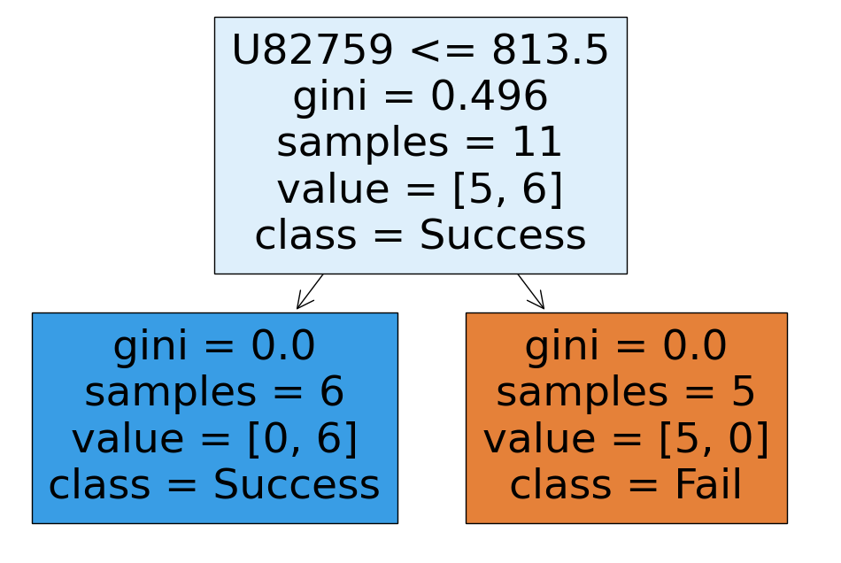

```
Most important predictor name: U82759
Pruned Accuracy (after top predictor removal): 50.00%
```

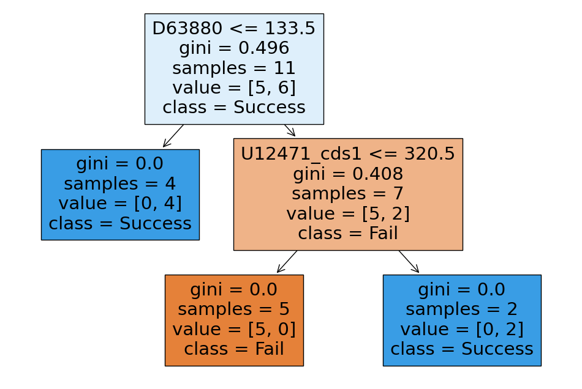

```
Base Tree - Sensitivity: 1.00, Specificity: 0.67
Pruned Tree - Sensitivity: 0.00, Specificity: 0.67
```

```python
from sklearn.metrics import confusion_matrix
from sklearn.model_selection import train_test_split
from sklearn import tree
import matplotlib.pyplot as plt

# Split data into given ratio 75:25 using sklearn built-in function
x_train, x_test, y_train, y_test = train_test_split(x_vals, y_vals, test_size=0.25, random_state=3)

# Train the DTC on train split
base_dtc = DecisionTreeClassifier(random_state=3)
base_dtc.fit(x_train, y_train)

# Print base accuracy before predictor removal
base_acc = base_dtc.score(x_test, y_test)
print(f"Base Accuracy (before top predictor removal): {base_acc * 100:.2f}%")

# Visualise the tree and find the most important predictor
plt.figure(figsize=(12, 8))
tree.plot_tree(base_dtc, feature_names=x_vals.columns, class_names=["Fail", "Success"], filled=True)
plt.show()

# Sanity check, can also be seen from graph above
ftr_idx = base_dtc.feature_importances_.argmax()
ftr_name = x_vals.columns[ftr_idx]
print(f"Most important predictor name: {ftr_name}")

# Remove the predictor from train data
x_train_pruned = x_train.drop(columns=[ftr_name])
x_test_pruned = x_test.drop(columns=[ftr_name])

# Train a new DTC for train attributes
pruned_dtc = DecisionTreeClassifier(random_state=3)
pruned_dtc.fit(x_train_pruned, y_train)

# Print new accuracy
pruned_acc = pruned_dtc.score(x_test_pruned, y_test)
print(f"Pruned Accuracy (after top predictor removal): {pruned_acc * 100:.2f}%")

# Visualise the pruned tree for comparison
plt.figure(figsize=(12, 8))
tree.plot_tree(pruned_dtc, feature_names=x_train_pruned.columns, class_names=["Fail", "Success"], filled=True)
plt.show()

# Calculating Sensitivity/Specificity for Q1.6

# Getting predictions
y_pred_base= base_dtc.predict(x_test)
y_pred_pruned = pruned_dtc.predict(x_test_pruned)

# Setting confusion matrices
# Format is [[TN, FP], [FN, TP]]
cm_base = confusion_matrix(y_test, y_pred_base)
cm_pruned = confusion_matrix(y_test, y_pred_pruned)

# Get base tree metrics
sensitivity_base = cm_base[1, 1] / (cm_base[1, 1] + cm_base[1, 0])
specificity_base = cm_base[0, 0] / (cm_base[0, 0] + cm_base[0, 1])

# Get pruned tree metrics
sensitivity_pruned = cm_pruned[1, 1] / (cm_pruned[1, 1] + cm_pruned[1, 0])
specificity_pruned = cm_pruned[0, 0] / (cm_pruned[0, 0] + cm_pruned[0, 1])

# Print calculated values
print(f"Base Tree - Sensitivity: {sensitivity_base:.2f}, Specificity: {specificity_base:.2f}")
print(f"Pruned Tree - Sensitivity: {sensitivity_pruned:.2f}, Specificity: {specificity_pruned:.2f}")
```

### Q1.5 Discussion [1], [2]

### Trees Preparation and results

After the data has been split into 75:25 train:test ratio, and the Decision Tree has been trained, we have obtained the following, `accuracy: 75%`. Then, that tree has been visualised using `tree.plot_tree()`, and the most important predictor has been chosen as `U82759`. It was then validated using tree's internal records.

Then, that predictor was removed, train data adjusted, and a new Decision Tree has been trained to include those changes. The following value has been obainted for the pruned tree, `accuracy: 50%`. Then, again, the tree has been visualised using `tree.plot_tree()`.

### Accuracy Comparison

Accuracy before removal: `75%`

Accuracy after removal: `50%`

We immediately notice an accuracy drop of 25%. This means that the top predictor `U82759`, which was the root of the base tree, was extremely important in classifying samples straight from the tree's base. It also implies that there was as strong correlation/association with ground truth; quite likely that a boundary condition for end decision was lost.

We also see that the base tree was much simpler, allowing for one decision node and and two leaf nodes corresponding to predicted results. When the predictor was removed, the new tree started relying on other features (most likely less important) to make decisions. Because of that, the tree had to grow in complexity, which resulted in an additional decision node and three leaf nodes.

When looking at the pruned tree's Gini values (messiness/randomness of a set), we see that although both root values are the same (0.496), the next decision node has Gini impurity of (0.408). Although the leaf nodes still have impurities of 0 (same as base), the general pruned tree's structure implies that model became less confident in its initial split and had to introduce an additional feature condition to make a decision and adequately split the samples.

In general, a decision tree with fewer nodes (with similar Gini impurity) can be seen as more confident due to fewer conditions required when making a decision. Moreover, more nodes might indicate that the tree is struggling to make clear decision boundaries (when strong predictor is missing), which results in having to introduce potentially weaker features to make the same predictions.

In summary, it is evident that `U82759` was extremely important when making the decision regarding treatment's success or failure. When removed, it forced a new tree structure, which had to rely on other features to make the predictions. These, as seen by accuracy drop, were less effective at appropriately distinguishing between treatment results.

#### References

[1] Decision Tree Classifier: https://scikit-learn.org/stable/modules/generated/sklearn.tree.DecisionTreeClassifier.html#sklearn.tree.DecisionTreeClassifier

[2] Tree Module: https://scikit-learn.org/stable/modules/tree.html#tree

## Q1.6 (2 marks)

Which tree do you think is more generalizable? You may want to more thoroughly compare the trees (readability, sensitivity/specificity, structure simplicity, etc.).

## Q1.6 Answer

### Discussion [1], [2], [3]

Model generalization is an important aspect of any data-driven design, and requires several factors to be evaluated. For this question, we will focus and discuss the following:

#### 1.Complexity/Structure Simplicity

Starting with the base tree, we see that it uses fewer features in order to make a prediction (only 1 at root) and trees that make decision based on fewer attributes are seen as more robust due to having rely on broader data characteristics and focus on straighter patterns. This in turn makes them less prone to be influenced by possible fluctuations between individual features. Such trees rely on more reliable/primary characterstics that represent data, rather than splitting focus on multiple features.

The pruned tree, on the other hand, has grown in complexity. Becuase of that, it has become more susceptible to minor details in training data. An increase in nodes indicates having to utilize more features in order to make decision, and these often are less reliable/alligned with the ground truth. This sometimes even might indicate the model starting to consider noise in order to fit better, which in turn makes it less generalizable.

#### 2. Readability

Simpler trees, or in general simpler models, are inherently much more readable than complex ones. With fewer nodes, it is much easier to follow the logic and understand each decision, and why it is happening. This, of course, makes possible trouble-shooting and refinement easier. It also makes the whole process much more transparent, making validation and/or explanation to outside people much more efficient.

More complex trees, in turn, make intepretation and following the process' logic harder and harder with each additional node. Such nodes can also introduce more confuision and more work needed when trying to explain and/or improve the model. This is especially the case when the features are not straightforward, such as genes.

#### 3. Accuracy

A 75% accuracy for the base model indicates a relatively good performance, as it is capable of predicting 3 out of 4 unseen samples correctly. This outcome, compared with model's simple structure, suggest that the chosen top indicator `U82759` captures significant information about the ground truth we are trying to predict, which of course guarantees somewhat high resultant accuracy.

With the pruned top predictor, we see an immediate drop of 25%. The resultant accuracy of 50% is equivalent of flipping a coin for each sample. This indicates that the model struggles to make correct decisions without the predictor present. Because of that, it tries compensating with other features, making it more prone to mistakes with other data.

#### 4. Sensitivity/Specificity

Obtained results:

Base Tree - Sensitivity: 1.00, Specificity: 0.67 Pruned Tree - Sensitivity: 0.00, Specificity: 0.67

As we can see, the base tree correctly identifies all of the positive cases, and 67% of the negative cases. For the pruned tree, it fails to identify any of the positive cases, but manages to also identify 67% of the negative cases. This difference is crucial, especially in this context, where appropriate treatment assesment and application can save lives.

#### 5. Confidence/Gini impurity

The base tree has a direct path from its base with relatively high Gini impurity to leaves with 0 impurity, which showcases a decisive split in its decision process and showcases a high confidence when deciding the ultimate treatment classification. Because the process is so straightforward, the model does not require any other features as back-up.

Although pruned tree's root impurity remains the same, the addition of another decision node before reaching 0 impurity indicates the newly utilized attributes do not offer the same level of confidence when making decisions. It also undermines the value of initial split, as it must be backed by further conditions. This of course introduces more potential error into the whole process.

#### Summary

In summary, while both trees aim to achieve the same goal, it is clear that the base tree is more likely to generalize better on new, unseen data. This is backed by its strenght in its simplicity and utilization of top predictor. The pruned tree tries to utilize secondary features to make its predictions, but these ultimately fall short. Not only is the tree more complex and harder to read, it also has worse accuracy and sensitivity. So, in terms of generalizability, the simpler (base) model can capture the main trend without having to try and overfit, while also maintaining a simple and easy to follow structure.

##### References

[1] Tan, P. N., Steinbach, M., & Kumar, V. (2006). Introduction to Data Mining. Addison-Wesley.

[2] Kuhn, M., & Johnson, K. (2013). Applied Predictive Modeling. New York: Springer.

[3] James, G., Witten, D., Hastie, T., & Tibshirani, R. (2013). An Introduction to Statistical Learning (Vol. 112). New York: Springer.

# Q2: Decision Boundaries (4 marks)

In this question, we will visualize the decision boundaries formed by three simple classifiers on an example dataset.

## Q2.1 (4 marks)

We have provided code below to produce the data and to create the decision boundary. You will need to run this code using the following models:

1. "ZeroR" classifier - `sklearn.dummy.DummyClassifier` using the `"most_frequent"` strategy.
2. KNN classifier - `sklearn.neighbors.KNeighborsClassifier`
3. Decision tree classifier - `sklearn.tree.DecisionTreeClassifier`

You will need to modify the code to output the accuracy for each of the models. Using both this information and the visualized decision boundaries, explain the performance of these algorithms. A brief explanation of the classifiers will be required for this.

**Hints:**

- Although not necessary, the use of further visualizations, performance measures, or even datasets may help to support your discussion
- Use the decision boundaries as a reference point to explain the **differences** between the classifiers.

```
Classification Report for ZeroR:
               precision    recall  f1-score   support

           0       0.50      1.00      0.67        50
           1       0.00      0.00      0.00        50

    accuracy                           0.50       100
   macro avg       0.25      0.50      0.33       100
weighted avg       0.25      0.50      0.33       100
```

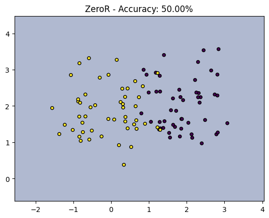

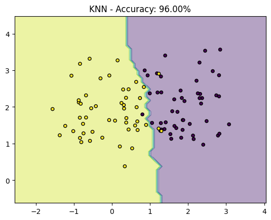

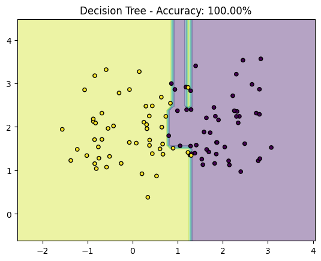

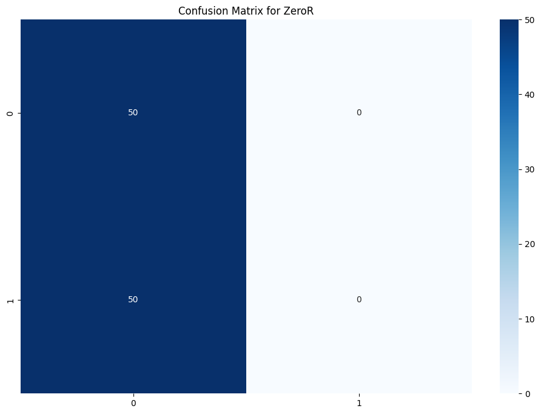

```
Classification Report for KNN:
               precision    recall  f1-score   support

           0       0.94      0.98      0.96        50
           1       0.98      0.94      0.96        50

    accuracy                           0.96       100
   macro avg       0.96      0.96      0.96       100
weighted avg       0.96      0.96      0.96       100
```

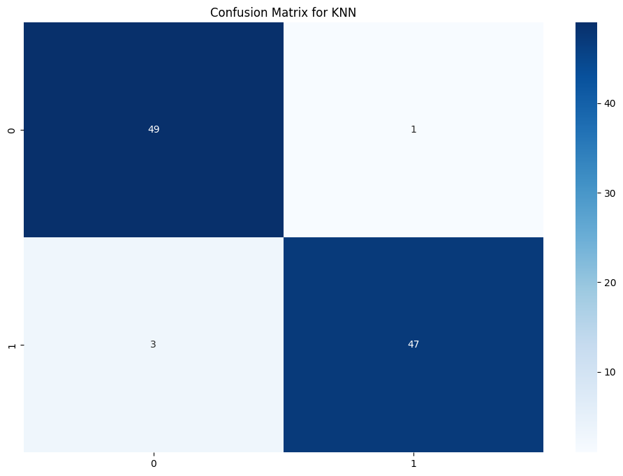

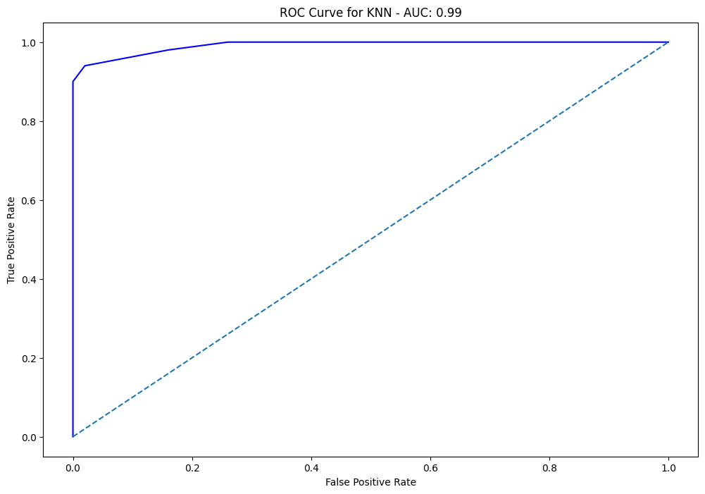

```
Classification Report for Decision Tree:
               precision    recall  f1-score   support

           0       1.00      1.00      1.00        50
           1       1.00      1.00      1.00        50

    accuracy                           1.00       100
   macro avg       1.00      1.00      1.00       100
weighted avg       1.00      1.00      1.00       100
```

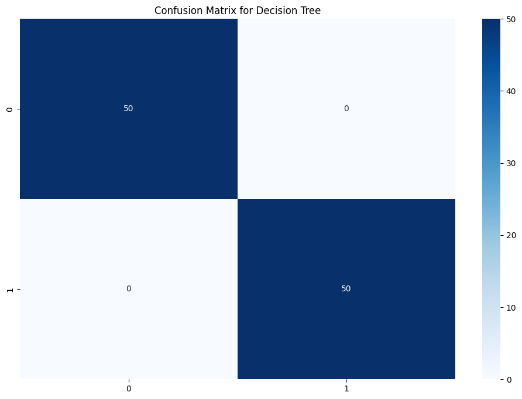

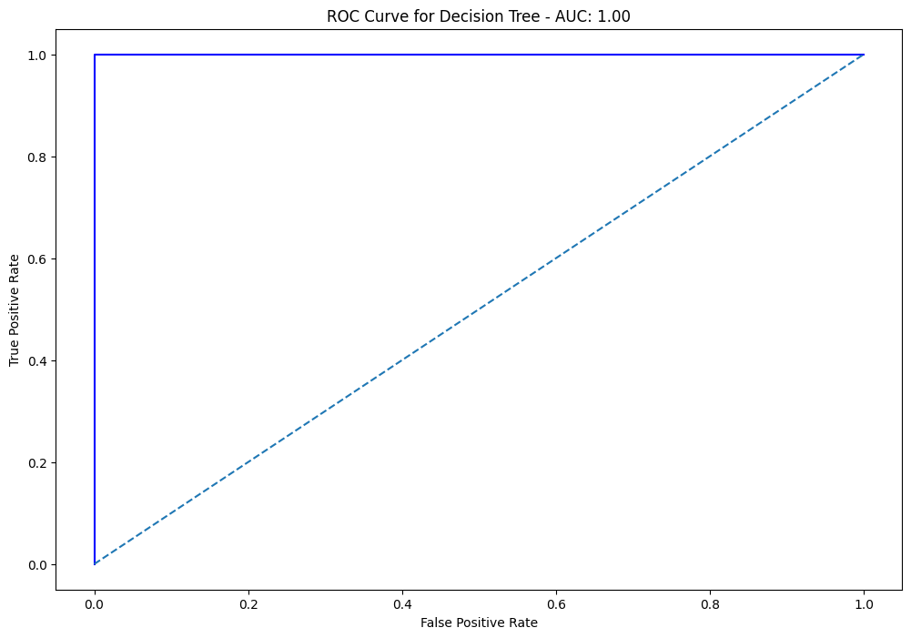

```python
"""
The code below provides you with the functions to get the data,
and plot the decision boundary.

The resulting graphs have not been properly formatted, however,
so you will need to add that. You will also need to modify the
code to output the accuracy.
"""

import numpy as np
from sklearn.datasets import make_classification

from sklearn.dummy import DummyClassifier
from sklearn.neighbors import KNeighborsClassifier
from sklearn.tree import DecisionTreeClassifier

from sklearn.metrics import classification_report, roc_auc_score, roc_curve
import seaborn as sns

def get_data():
    # Create data
    data, labels = make_classification(
        n_features=2, n_redundant=0, n_informative=2,
        random_state=1, n_clusters_per_class=1
    )
    # Set the RNG
    rng = np.random.RandomState(42)
    # Add some noise
    data += 2 * rng.uniform(size=data.shape)
    return data, labels

def plot_boundary(X, ax, clf):
    # Plotting decision regions
    x_min, x_max = X[:, 0].min() - 1, X[:, 0].max() + 1
    y_min, y_max = X[:, 1].min() - 1, X[:, 1].max() + 1
    xx, yy = np.meshgrid(
        np.arange(x_min, x_max, 0.1),
        np.arange(y_min, y_max, 0.1)
    )
    Z = clf.predict(np.c_[xx.ravel(), yy.ravel()])
    Z = Z.reshape(xx.shape)
    ax.contourf(xx, yy, Z, alpha=0.4)
    return ax

def boundary_full(data, labels, model, name, **kwargs):
    # Create estimator/model/classifier
    clf = model(**kwargs)
    # Fit the classifier
    clf.fit(data, labels)

    # Create axis
    _, ax = plt.subplots()
    # Call the provided function
    ax = plot_boundary(data, ax, clf)
    # Now add the data (using scatter)
    # Ensure to colour the points according to the prediction
    ax.scatter(data[:,0], data[:,1], c=labels, s=20, edgecolor="k")
    # Format the graph...
    ax.set_title(f"{name} - Accuracy: {clf.score(data, labels)*100:.2f}%")

def evaluate_model(model, data, labels, name):
    # Fit given model
    model.fit(data, labels)

    # Make predictions
    predictions = model.predict(data)

    # Generate and print a classification report
    print(f"Classification Report for {name}:\n {classification_report(labels, predictions, zero_division=0)}")

    # Get confusion matrix
    cm = confusion_matrix(labels, predictions)
    plt.figure(figsize=(12,8))
    plt.title(f"Confusion Matrix for {name}")
    sns.heatmap(cm, annot=True, fmt="d", cmap="Blues")
    plt.show()

    # Get AUC-ROC (when applicable; ZeroR will have AUC of 0.5)
    if name != "ZeroR":
        probs = model.predict_proba(data)[:, 1]
        auc = roc_auc_score(labels, probs)
        fpr, tpr, _ = roc_curve(labels, probs)
        plt.figure(figsize=(12,8))
        plt.title(f"ROC Curve for {name} - AUC: {auc:.2f}")
        plt.plot(fpr, tpr, color="blue")
        plt.plot([0, 1], [0, 1], linestyle="--")
        plt.xlabel("False Positive Rate")
        plt.ylabel("True Positive Rate")
        plt.show()

# Get data for testing
data, labels = get_data()

# "ZeroR" classifier plot
boundary_full(data, labels, DummyClassifier, "ZeroR", strategy="most_frequent")

# KNN classifier plot
boundary_full(data, labels, KNeighborsClassifier, "KNN")

# Decision tree classifier plot
boundary_full(data, labels, DecisionTreeClassifier, "Decision Tree")

# Further evaluations
evaluate_model(DummyClassifier(strategy="most_frequent"), data, labels, "ZeroR")
evaluate_model(KNeighborsClassifier(), data, labels, "KNN")
evaluate_model(DecisionTreeClassifier(), data, labels, "Decision Tree")
```

## Q2.1 Answer

### Discussion [1], [2], [3], [4], [5], [6]

#### ZeroR brief

The "ZeroR" classifier, also known as the Zero Rule algorithm, is the simplest type of classifier. It does not really "learn" nor try to implement complex decision strategies. It disregards virtually all information and only uses the target class labels to make its predictions. It does that through simply predicting the most frequent class in the training dataset for all samples. It usually stands as a comparison point, or a baseline, for more sophisticated and complex algorithms/models. Therefore, introduction of any other features than target is useless. The working of this can be described as:

1. Count the occurrences of each label in the training set data
2. Find the most frequent class
3. Predict most frequent class for all new data, regardless of their feature values

The decision boundary is virtually non-existent, as the class label assignment is done regardless of features.

#### KNN brief

K-Nearest Neighbours (KNN) is a type of an instance-based algorithm, where the model stores all instances of training data in a given feature space and classifies new entries based on a similarity measure. These measures are usually distance functions, such as Euclidean, Manhattan, and so on. A new entry is assigned to the class which has the most representatives within the nearest neighbours of that point (majority vote). The steps the algorithm follows are the following:

1. Store all instances of the training data
2. For a new incoming point, calculate the distance from the new point to all entries in the training data
3. Find K instances in the training data that are the closest to new point
4. Determine the most common label among those K nearest neighbours and assign that label to the new point

Decision boundaries are more nuanced, as they depend on the distribution of data within a given feature space. As the K value decreases, they can become more complex and irregular.

#### Decision tree brief

A Decision tree classifier utilizes several input features in order to predict the target variable. It does that through constructing a tree-like model of decisions, where each node acts like a test on a given attribute, and each branch a result of that test. The process starts at root node and later splits data on a given feature that results in the biggest information gain. This process is repeated over and over until the subtree contains only one class, or until it contains nodes with all equal values. The steps are as follows:

1. Start at the root node
2. Split the data based on the attribute that results in the largest information gain
3. Repeat the process on data obtained from the split until all samples in the subsets belong to a single class, or until a given depth is reached

The decision boundaries for trees can be axis-aligned and piecewise linear, as they reflect the splitting process. As each split seperates the space into two regions, repeated recursively, these boundaries can be seen as straight seperation lines for each node in the space.

#### Differences between classifiers and resultant performance

##### ZeroR

This is further solidified thanks to the confusion matrix and classification report, where we see that while the classifier correctly identifies instances of one class, it completely failed to recognize any instance of the second class. It can be stated, that due to the algorithm's nature, the accuracy and resultant performance indicator simply reflect the distribution of the most common class in the dataset. Resultantly, the ROC curve would simply be a diagonal line, meaning no discriminative power.

The most evident difference from other classifiers is the complete lack of any decision boundaries, meaning no attempts at segregation, which means that the classifier will perform poorly on any dataset that is not dominated by a single class, making it awkward to apply for any other reason than benchmarking.

##### KNN

For this classifier, we notice boundaries based on distance, which correspond to regions where each class is predicted. We also notice a more irregular split between boundaries, being resultant of localized patterns and classifications based on nearest neighbors. Given the algortihms nature, where classification is dependant on data distribution within the feature space, this is expected. However, these shapes could be even more irregular and fine-grained if we were to lower the K value.

With the `accuracy` of this approach being `96%`, being much higher than the ZeroR benchmark, we see that the more complex split of the feature space is better at differentiating between nuances in the data. This can be further solidified thanks to the increase in matrix and classification report values. Although not perfect, the values represent the algorithm's ability to capture the trends and features much better; an `AUC of 0.99` from the ROC curve indicates that the algorithm is has a high TP rate and a low FP rate, showcasing the ability to distinguish between classes effectively. This would be seen even better if small islands of points were present, however, this is not the case here.

The resultant 4 missjudged data points are due them being noisy and extremely hard to capture right without overfitting. As visible from the boundary condition and confusion matrix plots, these points are outliers and should most likely be discarded before fitting the model. However, they stand to showcase how the algorithm reacts to data that does not allign well with the general underlying trends, such as noise.

The most noticable differences are because of the point assignment based on majority vote of K-neighbours. The decision boundaries are more delicate and can adapt to fine-grained patterns in the data without overfitting much when applied correctly. However, too loose rules can make it overfit.

##### Decision tree

As predicted, for this approach, we see linear boundaries based on the tree's decision nodes, leading to rectangular sections of the feature space, where each class is dominantly predicted. This visualisation corresponds to the method's nature of creating rules based on given features to maximize the information gain. Given the specifics of how the algorithm handles its decision process, we see the regions/splits being made in a hierarchical manner, making the corresponding shapes better defined and linear.

Due to the decision tree's method of splitting the feature space based on attributes and rules, we see the resultant spaces containing only points of that class. With the `accuracy` being `100%`, and resultant matrix and classification report values, we see that not a single point has been missjudged or wrongly assigned. This represent the algorithm's ability to capture all trends and smallest details within the data; an `AUC of 1.00` further solidifies the lack of mistakes, emphasizing its distinction power between classes based on nuances.

However, having all of these points being correctly assigned does not have necessarily be a good indicator. As we see from the boundary plot, these contours look rather odd, having to split to cover all points, including added noise. Because of that we see that the model has created data-specific rules trying to cover all points in the data, making it less applicable and generalizable to unseen data. This performance is tied to the tree's depth; too shallow and the model will overfit, too deep and the model will overfit. The latter is the case here.

The most notable difference is of course the way boundaries are crated. Because of binary splits during decision process, the resultant shapes are more structured and result in clear rectangular splits in the space. Ultimately, of course depending on the tree's depth, this can make them very balanced at capturing trends.

#### Summary

ZeroR is just a baseline model with no real decision boundaries; its performance is uniform and dependant on data distribution. There is no insight given into the feature space.

KNN adapts to the feature space via distance-based methods and can display complex boundaries based on data. It is sensitive to local patterns, but can overfit when being made too flexible.

Decision Trees represent a hierachical approach, being represent by linear and structured decision boundaries regions. They can offer a balanced way of representing data, but this very much varies on the trees depth.

These differences underscore the trade-offs between simplicity and accuracy, overfitting and generalization capabilities, and between model interpretability and the ability to capture complex relationships in the data.

##### References

[1] Dummy Classifier: https://scikit-learn.org/stable/modules/generated/sklearn.dummy.DummyClassifier.html

[2] KNN Classifier: https://scikit-learn.org/stable/modules/generated/sklearn.neighbors.KNeighborsClassifier.html

[3] Decision Tree Classifier: https://scikit-learn.org/stable/modules/generated/sklearn.tree.DecisionTreeClassifier.html

[4] ROC Plot: https://scikit-learn.org/stable/auto_examples/model_selection/plot_roc.html

[5] Bishop, C. M. (2006). Pattern Recognition and Machine Learning. Springer.

[6] Hastie, T., Tibshirani, R., & Friedman, J. (2009). The Elements of Statistical Learning. Springer.

# Question 3: Training Time Comparison (4 marks)

## Q3.1 (2 marks)

Plot the training time for both `DecisionTreeClassifier` and `GaussianNB` against the data size. A function to generate the data is provided to you, which takes the size as its only argument.

Explain what you observe and your understanding in terms of training time and data size (include a graph). Consider algorithm implementation and potential stochasticity in running times.

```python
# Use this function to measure the time
from time import time

# Use this function to generate the data
def create_data(size):
    # Create data
    data, labels = make_classification(
        n_samples=size,
        n_features=2, n_redundant=0, n_informative=2,
        random_state=4, n_clusters_per_class=1
    )
    return data, labels
```

## Q3.1 Answer

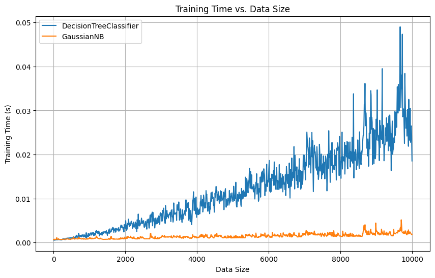

```python
from sklearn.naive_bayes import GaussianNB

# Initialize arrays to store training time for each classifier
dtc_times = []
gnb_times = []

# Create test sizes, ranging from 1 to 10,000 in increments of 10
sizes = list(range(1, 10001, 10))

# Loop through sizes and save train time for each method
for size in sizes:
    data, labels = create_data(size)

    # Measure and save the time for DTC
    start = time()
    dtc = DecisionTreeClassifier()
    dtc.fit(data, labels)
    end = time()
    dtc_times.append(end - start)

    # Measure and save the time for GNB
    start = time()
    gnb = GaussianNB()
    gnb.fit(data, labels)
    end = time()
    gnb_times.append(end - start)

# Plot the resultant train times
plt.figure(figsize=(10, 6))
plt.plot(sizes, dtc_times, label="DecisionTreeClassifier")
plt.plot(sizes, gnb_times, label="GaussianNB")
plt.xlabel("Data Size")
plt.ylabel("Training Time (s)")
plt.legend()
plt.title("Training Time vs. Data Size")
plt.grid(True)
plt.show()
```

### Q3.1 Discussion [1], [2], [3]

Based on the above plot representing train times for different dataset sizes, we can conclude the following:

1. Training time and fluctuations - although both methods have relatively low training times even at larger datasizes (never breaching 0.05s), we can see that the Decision Tree Classifier increases somewhat linearly with the size, whereas the Gaussian Naive Bayes seems to stay stable and constant. Fluctuations in the training time are visible for both methods, however, the DTC's ones are much more pronounced and erratic, whereas GNB are much calmer.
2. Stochasticity - the resultant variations and fluctuations can be further attributed to the inherent nature of both methods, especially for the DTC. This is the result of how the trees are built, which is especially pronounced when there is randomness in features splits. While traditional DTC is deterministic for a fixed dataset and set of hyperparameters, the randomness can occur from situations like: data splitting - feature split might be choosen randomly if two features provide the same information gain, random features subsets, or bootstrapping techniques. However, a basic DTC will generally produce the same tree when trained with the same hyperparameters and data unless there is a tie a feature split criterion. Although standard GNB is also deterministic, and will always compute the same class priors and feature likelihoods given a dataset, it can be influenced. These variations can cone in forms of initialization, handling zero probabilities, feature selection and data order. However, in general, for a traditional GNB, any stochasticity arises purely from specific extensions or variations of the algorithm, or preprocessing steps.
3. Algorithm complexity and implementation - the training complexity of a DTC is typically O(n*m*log(m)), where n is the number of features and m is the number of samples. However, the tree is often pruned and doesn’t grow to the fullest extent. Moreover, the actual applications often include other heuristics and optimization methods, such as using random feature subsets or limiting the tree's depth, decreasing the complexity. The GNB, under the assumption of normally distributed data, has a training complexity of O(n*m). It also utilizes statistical operations such as mean and variance for each class-feature combination. However, the inherent simplicity of underlying math operations translates into more efficient software implementations. Still, certain aspects, such as underflow for small probabilities, can sometimes affect the efficiency. These behaviour differences in both pure and modified implementations further explain the visible trends in the graph and resultant differences in training times between both methods when datasize becomes larger and larger.

#### Summary

While both methods have proven to be efficient in the given working environment, it has become apparent that DTC showcases more variability and increased training time with larger datasets. This is due to its algorithmic complexity and the somewhat stochastic nature of the mechanism behind decision tree building. On the other hand, GNB maintains consistent and linear performance, due to its simpler mathematical background and more deterministic nature.

#### References

[1] Decision Tree Classifier: https://scikit-learn.org/stable/modules/generated/sklearn.tree.DecisionTreeClassifier.html

[2] Gaussian Naive Bayes: https://scikit-learn.org/stable/modules/generated/sklearn.naive_bayes.GaussianNB.html

[3] Hastie, T., Tibshirani, R., & Friedman, J. (2009). The Elements of Statistical Learning. Springer.

## Q3.2 (2 marks)

What do you think would happen if we continue increasing the number of instances? Which of the algorithms would be more suitable for a very large number of instances and why? Consider the algorithms’ complexity and how they scale.

## Q3.2 Answer

As previously noticed, with the increased number of instances the expected training time for DTC would increase at a much more noticable rate than GNB. But in order to answer the question at hand, let us also focus on the following:

1. Scalability and suitability for large datasets - GNB scales better with increased number of either instances or features due to its less demanding computational operations regarding statistics. Because of that, it is more suited to handle larger and more varied datasets, especially when the resources and latency are limiting factors.
2. Algorithmic complexity - as previously stated, DTC has a training time complexity of O(n*m*log(m)), whereas GNB has O(n*m), where n is the number of features and m is the number of samples. Immediately, we see that DTC is much more sensitive to increase in data size or features, and while operations like pruning or limiting tree's depth can help, they do not fix the inherent method's complexity, rendering it expensive for very large datasets
3. Possible trade-offs - of course, when talking about suitability, scalability and latency should not be the only factors. Other important factors might include performance, interpretability, or inherent nature of data. A method can be both fast and scalable, but might be unusuable in some cases.

In summary, if our primary goal is to minimize training time and ensure the scalability of our approach, GNB is the much more suitable choice. However, other factors should also be included in that comparison to ensure completely appropriate selection.

# Question 4: Memory Usage Comparison (3 marks)

# Q4.1 (3 marks)

Plot the memory usage of the `DecisionTree` model against the data size. Explain the memory usage of the model (including a graph in your answer).

You should use the same `create_data()` function provided for Q3, and ensure that you have downloaded `memory.py` from Blackboard in order to load the `measure_memory()` function.

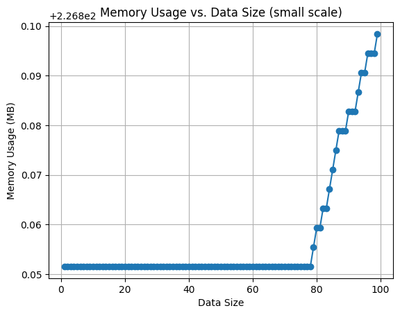

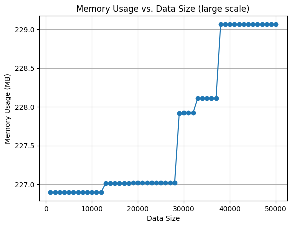

```python
!pip3 install memory-profiler
from memory import measure_memory

# Initalize an array to store resultant memory usages
memory_usages_small = []
memory_usages_large = []

# Create test data sizes
# ranging from 1 to 100 in increments of 1 for small scale
# and ranging from 1000 to 50,000 in increments of 1000 for large scale
data_sizes_small = list(range(1, 100, 1))
data_sizes_large = list(range(1000, 50001, 1000))

# Loop through sizes and save train time for each method and scale
for size in data_sizes_small:
    data, labels = create_data(size)
    dtc = DecisionTreeClassifier()
    memory_usage = measure_memory(data, labels, dtc)
    memory_usages_small.append(memory_usage)

for size in data_sizes_large:
    data, labels = create_data(size)
    dtc = DecisionTreeClassifier()
    memory_usage = measure_memory(data, labels, dtc)
    memory_usages_large.append(memory_usage)

# Plot the results
plt.plot(data_sizes_small, memory_usages_small, marker="o")
plt.title("Memory Usage vs. Data Size (small scale)")
plt.xlabel("Data Size")
plt.ylabel("Memory Usage (MB)")
plt.grid(True)
plt.show()

plt.plot(data_sizes_large, memory_usages_large, marker="o")
plt.title("Memory Usage vs. Data Size (large scale)")
plt.xlabel("Data Size")
plt.ylabel("Memory Usage (MB)")
plt.grid(True)
plt.show()
```

## Q4.1 Answer

From the obtained graphs, we can notice the following:

On both scales we see that there are apparent thresholds where memory consumption rises sharply. This behaviour indicates that decision trees can handle growing datasets efficiently until they reach certain complexities/threshold, at which they require structural changes to accomodate new data and trends, leading to higher memory needs.

However, the model showcases somewhat impressive memory efficiency, handling both small and notably large datasets without a direct proportionate, linear, or otherwise unsustainable increase in memory usage.

Given this behavior, we should expect potential sudden memory spikes, especially when approaching data size thresholds, for example as seen in above graphs.

In summary, DTC exhibits periods of memory efficiency followed by sharp memory usage spikes at specific size thresholds. These spikes are the result of the tree having to change its structure to accomodate new data and trends found within. Of course, it only need to do that periodically, as after a given structure modification, the tree can handle more data until a new threshold is reached. Then, the process of restructurization repeats, and so the memory usage increases again.